# Business Report Assessment 3

Muhammad Ayaz M Haque and Naga

2022-03-31

## Loading all libraries

```r
library(tidyverse)
library(skimr)
library(broom)
library(forcats)
library(randomForest)
library(caret)
library(rattle)
```

## Backgroud of dataset:

The data comes from Sharla Gelfand’s opendatatoronto R package, Data originally sourced from this link. we are going to name the dataset as shelters.

Article around Homeless Shelters in Toronto.

## Data Wrangling:

Initially we are going to connect the dataset and explore the dataset provided, we will be doing the following steps to make our data more useful for visualization and modelling.

1. Loading data
2. Converting character variables into the factors
3. Extracting the days, months and year from the date column

### 1. Loading data:

Here we are loading the data from the internet.

```r
shelters <- readr::read_csv('https://raw.githubusercontent.com/rfordatascience/tidytuesday/master/data/2020/2020-12-01/shelters.csv')
```

#### 1.a Showing the head of the head and summary of dataset:

This shows the top rows (observations) of the dataset and also shows the summary of the dataset. Skim function show the nature of the variables(features) of the observation (row).

```r
shelters %>% head()
```

```
## # A tibble: 6 × 13
##      id occupancy_date      organization_name       shelter_name shelter_address
##   <dbl> <dttm>              <chr>                   <chr>        <chr>
## 1     1 2017-01-01 00:00:00 COSTI Immigrant Servic… COSTI Recep… 100 Lippincott…
## 2     2 2017-01-01 00:00:00 Christie Ossington Nei… Christie Os… 973 Lansdowne …
## 3     3 2017-01-01 00:00:00 Christie Ossington Nei… Christie Os… 973 Lansdowne …
## 4     4 2017-01-01 00:00:00 Christie Refugee Welco… Christie Re… 43 Christie St…
## 5     5 2017-01-01 00:00:00 City of Toronto         Birchmount … 1673 Kingston …
## 6     6 2017-01-01 00:00:00 City of Toronto         Birkdale Re… 1229 Ellesmere…
## # … with 8 more variables: shelter_city <chr>, shelter_province <chr>,
## #   shelter_postal_code <chr>, facility_name <chr>, program_name <chr>,
## #   sector <chr>, occupancy <dbl>, capacity <dbl>
```

#### 1.b Summary of dataset:

The data set we have has 13 variables and 115916 observations, out of 13 variables 9 are characters, 3 are numeric and one is POSIXct Firstly, we will convert the few character variables into factors

```r
skim(shelters)
```

Data summary

| Name | shelters |
| --- | --- |
| Number of rows | 115916 |
| Number of columns | 13 |
| _______________________ |  |
| Column type frequency: |  |
| character | 9 |
| numeric | 3 |
| POSIXct | 1 |
| ________________________ |  |
| Group variables | None |

**Variable type: character**

| skim_variable | n_missing | complete_rate | min | max | empty | n_unique | whitespace |
| --- | --- | --- | --- | --- | --- | --- | --- |
| organization_name | 0 | 1.00 | 9 | 39 | 0 | 33 | 0 |
| shelter_name | 0 | 1.00 | 9 | 32 | 0 | 65 | 0 |
| shelter_address | 0 | 1.00 | 12 | 32 | 0 | 65 | 0 |
| shelter_city | 0 | 1.00 | 7 | 11 | 0 | 4 | 0 |
| shelter_province | 0 | 1.00 | 2 | 2 | 0 | 1 | 0 |
| shelter_postal_code | 5494 | 0.95 | 6 | 7 | 0 | 62 | 0 |
| facility_name | 0 | 1.00 | 4 | 32 | 0 | 114 | 0 |
| program_name | 0 | 1.00 | 7 | 65 | 0 | 155 | 0 |
| sector | 0 | 1.00 | 3 | 8 | 0 | 5 | 0 |

**Variable type: numeric**

| skim_variable | n_missing | complete_rate | mean | sd | p0 | p25 | p50 | p75 | p100 | hist |
| --- | --- | --- | --- | --- | --- | --- | --- | --- | --- | --- |
| id | 0 | 1 | 19325.92 | 11164.58 | 1 | 9660 | 19320 | 28979.25 | 39446 | ▇▇▇▇▇ |
| occupancy | 0 | 1 | 56.97 | 83.19 | 0 | 13 | 37 | 69.00 | 826 | ▇▁▁▁▁ |
| capacity | 343 | 1 | 60.53 | 92.60 | 0 | 16 | 40 | 71.00 | 902 | ▇▁▁▁▁ |

**Variable type: POSIXct**

| skim_variable | n_missing | complete_rate | min | max | median | n_unique |
| --- | --- | --- | --- | --- | --- | --- |
| occupancy_date | 0 | 1 | 2017-01-01 | 2019-12-31 | 2018-07-03 | 1095 |

### 2. Coverting character variables into the factors:

Varibles are of two types numeric and categorical, categorical are mostly the text format. to apply the regression and modelling we need to convert the text variables into the factors. in the following step we converted useful text columns into the factors.

```r
shelters$organization_name = as.factor(shelters$organization_name)
shelters$shelter_name = as.factor(shelters$shelter_name)
shelters$shelter_address = as.factor(shelters$shelter_address)
shelters$shelter_city = as.factor(shelters$shelter_city)
shelters$sector = as.factor(shelters$sector)
shelters$shelter_province = as.factor(shelters$shelter_province)
shelters$shelter_postal_code = as.factor(shelters$shelter_postal_code)
shelters$facility_name = as.factor(shelters$facility_name)
shelters$program_name = as.factor(shelters$program_name)
```

#### 2.a Checking the structure of the dataset:

```r
str(shelters)
```

```
## spec_tbl_df [115,916 × 13] (S3: spec_tbl_df/tbl_df/tbl/data.frame)
##  $ id                 : num [1:115916] 1 2 3 4 5 6 7 8 9 10 ...
##  $ occupancy_date     : POSIXct[1:115916], format: "2017-01-01" "2017-01-01" ...
##  $ organization_name  : Factor w/ 33 levels "Christie Ossington Neighbourhood Centre",..: 5 1 1 2 3 3 3 3 3 3 ...
##  $ shelter_name       : Factor w/ 65 levels "Birchmount Residence",..: 6 3 3 4 1 2 2 10 16 16 ...
##  $ shelter_address    : Factor w/ 65 levels "100 Lippincott Street",..: 1 64 64 39 13 6 6 11 38 38 ...
##  $ shelter_city       : Factor w/ 4 levels "Etobicoke","North York",..: 4 4 4 4 4 4 4 4 4 4 ...
##  $ shelter_province   : Factor w/ 1 level "ON": 1 1 1 1 1 1 1 1 1 1 ...
##  $ shelter_postal_code: Factor w/ 62 levels "M1E 2M6","M1K 1M2",..: 37 55 55 53 NA 6 6 NA 1 1 ...
##  $ facility_name      : Factor w/ 114 levels "129 Peter St",..: 24 11 11 13 6 7 8 32 38 39 ...
##  $ program_name       : Factor w/ 155 levels "[Closed]Second Base - Extreme Weather Program",..: 31 17 18 20 9 13 11 38 44 45 ...
##  $ sector             : Factor w/ 5 levels "Co-ed","Families",..: 1 3 3 2 3 2 2 3 2 1 ...
##  $ occupancy          : num [1:115916] 16 13 63 66 58 168 119 23 8 14 ...
##  $ capacity           : num [1:115916] 16 17 63 70 60 160 150 28 0 40 ...
##  - attr(*, "spec")=
##   .. cols(
##   ..   id = col_double(),
##   ..   occupancy_date = col_datetime(format = ""),
##   ..   organization_name = col_character(),
##   ..   shelter_name = col_character(),
##   ..   shelter_address = col_character(),
##   ..   shelter_city = col_character(),
##   ..   shelter_province = col_character(),
##   ..   shelter_postal_code = col_character(),
##   ..   facility_name = col_character(),
##   ..   program_name = col_character(),
##   ..   sector = col_character(),
##   ..   occupancy = col_double(),
##   ..   capacity = col_double()
##   .. )
##  - attr(*, "problems")=<externalptr>
```

Here we can see all the character(text) variables have been converted into the factors

### 3. Extracting the days, months and year from the date variable:

In this section we are going to extract the days, months and year.

```r
shelters <- shelters %>%
  mutate(
    year = format(as.Date(shelters$occupancy_date),"%Y"),
    month = format(as.Date(shelters$occupancy_date),"%m"),
    day = weekdays(as.Date(shelters$occupancy_date)),
    )
```

# Data visualization:

in this section, we have created four different visualisations. these visuals help to understand the data better with the help of bar charts. it mainly shows the distribution of repites in different cities, sectors and trend of people going getting into the shelters. below is the list of the visuals we made to explore and understand our data. We have made few questions and tried to answer them through visualisation

1. How the sectors of different shelters are distribute over the cities?
2. Which city has the most vacancy and how is it different then other cities?
3. People are getting into shelters all our the year or is seasonal? Please show through any visualisation
4. Does this transaction depend on any perticular day of the week? Please break your visual further into differen t yaer

### 1. How the sectors of different shelters are distributed over the cities?

This is the stack column chart which shows the percentage of shelters available in different cities as per their sectors.Here we can see Etobicoke and NorthYoke has shelters only of Youth, however, Scarborough has three more sectors Women, Men and co-ed and finally Toronto has all five sectors which has Families additional

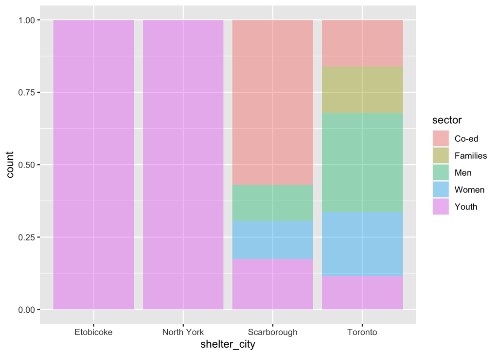

```r
# distribution of shelter home as per the sectors in different cities

shelters %>%
  ggplot(
  aes(shelter_city, fill = sector)) +
  geom_bar(position = "fill", alpha=0.4) +
  theme_gray()
```

### 2. Which city has the most vacacny and how is it different then other cities?

In this table we tried to find out the numbers of capacity, occupancy and vacancy in all the respites in all the data set. here we chose this visuals because these number is very large for Toronto compare to other cities.

```r
# table shows the vacancy in different cities

knitr::kable(shelters %>%
  group_by(shelter_city) %>%
  summarise(
  total_occupancy = sum(occupancy, na.rm = TRUE),
  total_capacity = sum(capacity, na.rm = TRUE),
  vacancy = total_capacity - total_occupancy
))
```

| shelter_city | total_occupancy | total_capacity | vacancy |
| --- | --- | --- | --- |
| Etobicoke | 57111 | 57993 | 882 |
| North York | 78153 | 79935 | 1782 |
| Scarborough | 145813 | 149452 | 3639 |
| Toronto | 6322682 | 6708122 | 385440 |

### 3. People are getting into shelters all our the year or is it seasonal? Please show through any visualisation

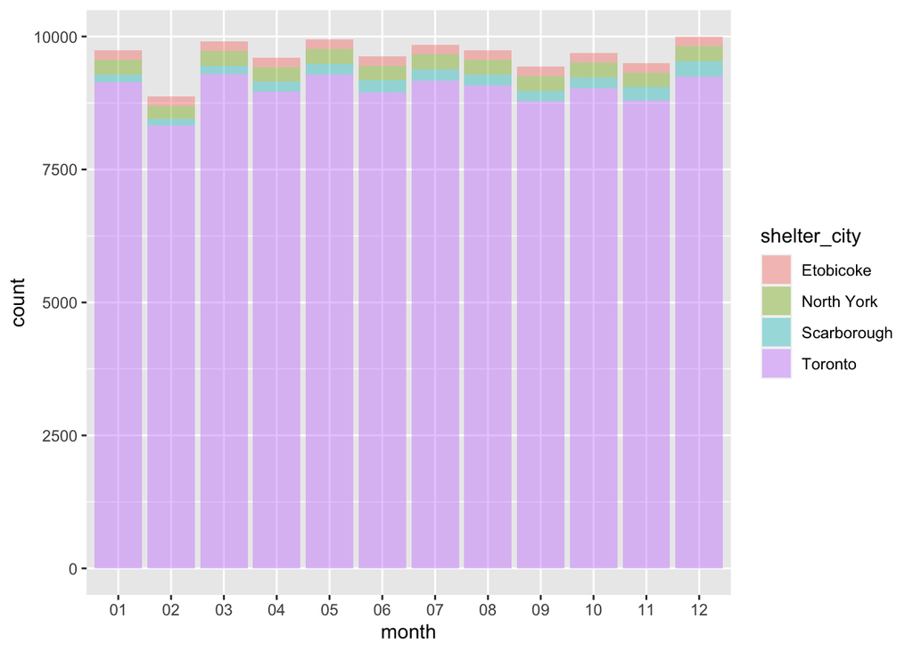

```r
shelters %>% ggplot(
  aes(x= month, fill=shelter_city)) +
  geom_bar(alpha= 0.4) +
  theme_gray()
```

### 4. Does this transaction depend on any perticular day of the week? Please break your visual further into different year

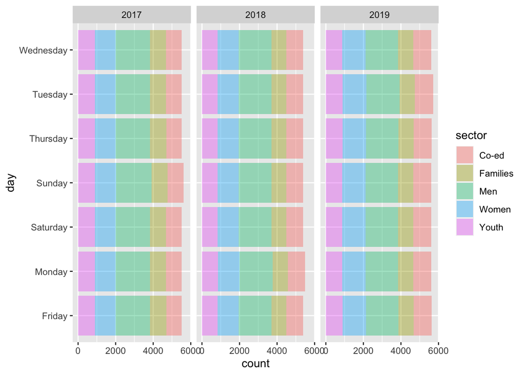

```r
shelters %>%  ggplot(
  aes(day, fill=sector)) +
  geom_bar(alpha=0.4) +
  facet_wrap(~year)+
  coord_flip()
```

## Data Modelling

The data modelling is technique to see what are the factors or variables which are effecting our out variables. in this case we have one dependent variable which has dependency on the other variables which can one or more.

The data set we have does not deal with any monetary transaction. this data set is used to improve the respite service provided to the homeless.

Here we are going to develop following two models.

1. Linear regression models between
- where capacity is the outcome(dependent) on other variables (factors)
- where occupancy is the outcome(dependent) on other variables (factors)

### Linear Regression

#### Capacity as an outcome

We have analysed our data set and found out there are missing values of capacity which need to be removed first and then run the modelling. Here we would like see if the capacity of the respite depends on the shelter name and program name or not?

```r
shelters_lm <- shelters %>% filter(
  !is.na(capacity) & !is.na(shelter_postal_code))

model_1 <- lm(capacity ~ shelter_name + program_name , data = shelters_lm)
summary(model_1)
```

```
##
## Call:
## lm(formula = capacity ~ shelter_name + program_name, data = shelters_lm)
##
## Residuals:
##    Min     1Q Median     3Q    Max
## -579.5    0.0    0.0    0.0  262.5
##
## Coefficients: (59 not defined because of singularities)
##                                                                                 Estimate
## (Intercept)                                                                    2.000e+00
## shelter_nameChristie Ossington Men's Hostel                                    3.189e+01
## shelter_nameChristie Refugee Welcome Centre                                    7.380e+01
## shelter_nameCornerstone Place                                                  5.211e+01
## shelter_nameCOSTI Reception Centre                                             1.400e+01
## shelter_nameCovenant House                                                     2.600e+01
## shelter_nameDixon Hall - Heyworth House                                        7.639e+01
## shelter_nameDixon Hall - Schoolhouse                                           4.329e+01
## shelter_nameDownsview Dells                                                    2.600e+01
## shelter_nameEagles Nest Transition House                                       1.000e+01
## shelter_nameEva's Phoenix                                                      4.800e+01
## shelter_nameEva's Place                                                        3.800e+01
## shelter_nameEva's Satellite                                                   -1.000e+00
## shelter_nameFamily Residence                                                   8.677e+01
## shelter_nameFife House Transitional Program                                    9.000e+00
## shelter_nameFort York Residence                                                4.600e+01
## shelter_nameFred Victor Women's Hostel                                         3.908e+01
## shelter_nameFred Victor, BUS                                                   5.800e+01
## shelter_nameFV Women's Transition to Housing                                   2.294e+01
## shelter_nameGood Shepherd Centre                                               2.300e+01
## shelter_nameHFS - Kennedy Shelter                                              8.043e+01
## shelter_nameHFS - Savard's Womens' Shelter                                     2.800e+01
## shelter_nameHFS - Scarborough Shelter                                          1.033e+02
## shelter_nameHFS - Strachan House                                               8.100e+01
## shelter_nameHorizons for Youth                                                 4.300e+01
## shelter_nameKennedy House Youth shelter                                        3.462e+01
## shelter_nameKennedy House Youth Shelter                                        3.800e+01
## shelter_nameNa-Me-Res                                                          1.800e+01
## shelter_nameRed Door Queen Street                                              9.820e+01
## shelter_nameRobertson House                                                    8.800e+01
```

[output cut: 975 more lines]

```
## program_nameYouth without Shelter Emergency Shelter Program                   ***
## program_nameYouth without Shelter Stay In School Program
## program_nameYouthLink Emergency Program                                       ***
## program_nameYouthLink Transitional Program
## program_nameYWCA - Adult Women Shelter
## program_nameYWCA - Youth Shelter
## program_nameYWCA Davenport - Adult                                            ***
## program_nameYWCA Davenport - Youth
## program_nameYWCA.BeatriceHouse.Transitional Housing
## ---
## Signif. codes:  0 '***' 0.001 '**' 0.01 '*' 0.05 '.' 0.1 ' ' 1
##
## Residual standard error: 30.88 on 109936 degrees of freedom
## Multiple R-squared:  0.8936, Adjusted R-squared:  0.8934
## F-statistic:  6500 on 142 and 109936 DF,  p-value: < 2.2e-16
```

```r
tidy(model_1)
```

```
## # A tibble: 202 × 5
##    term                                   estimate std.error statistic   p.value
##    <chr>                                     <dbl>     <dbl>     <dbl>     <dbl>
##  1 (Intercept)                                2.00      1.98      1.01 3.13e-  1
##  2 shelter_nameChristie Ossington Men's …    31.9       2.19     14.6  6.36e- 48
##  3 shelter_nameChristie Refugee Welcome …    73.8       2.19     33.7  1.02e-247
##  4 shelter_nameCornerstone Place             52.1       2.19     23.8  7.84e-125
##  5 shelter_nameCOSTI Reception Centre        14.0       2.19      6.39 1.64e- 10
##  6 shelter_nameCovenant House                26.0       2.19     11.9  1.72e- 32
##  7 shelter_nameDixon Hall - Heyworth Hou…    76.4       2.19     34.9  3.75e-265
##  8 shelter_nameDixon Hall - Schoolhouse      43.3       2.19     19.8  8.27e- 87
##  9 shelter_nameDownsview Dells               26.0       2.56     10.2  2.81e- 24
## 10 shelter_nameEagles Nest Transition Ho…    10.0       2.19      4.57 4.97e-  6
## # … with 192 more rows
```

#### Occupancy as an outcome:

Here e have seen the occupancy column has no missing values, hence we do not need to filter the missing values. In this model we want to analyse if the occupancy of the respites depends on the shelter city and the sector it belong to

```r
model_2 <- lm(occupancy ~ shelter_city + sector, data = shelters)
summary(model_2)
```

```
##
## Call:
## lm(formula = occupancy ~ shelter_city + sector, data = shelters)
##
## Residuals:
##     Min      1Q  Median      3Q     Max
## -153.38  -29.66   -6.08   12.39  672.62
##
## Coefficients:
##                         Estimate Std. Error t value Pr(>|t|)
## (Intercept)              26.7507     1.7527  15.262  < 2e-16 ***
## shelter_cityNorth York   -2.2872     1.9928  -1.148    0.251
## shelter_cityScarborough  32.2016     2.2235  14.482  < 2e-16 ***
## shelter_cityToronto       6.5326     1.6711   3.909 9.27e-05 ***
## sectorFamilies          120.0980     0.7702 155.922  < 2e-16 ***
## sectorMen                17.7483     0.6539  27.144  < 2e-16 ***
## sectorWomen               0.3759     0.7077   0.531    0.595
## sectorYouth              -0.6726     0.8303  -0.810    0.418
## ---
## Signif. codes:  0 '***' 0.001 '**' 0.01 '*' 0.05 '.' 0.1 ' ' 1
##
## Residual standard error: 72.24 on 115908 degrees of freedom
## Multiple R-squared:  0.246,  Adjusted R-squared:  0.246
## F-statistic:  5403 on 7 and 115908 DF,  p-value: < 2.2e-16
```

```r
tidy(model_2)
```

```
## # A tibble: 8 × 5
##   term                    estimate std.error statistic   p.value
##   <chr>                      <dbl>     <dbl>     <dbl>     <dbl>
## 1 (Intercept)               26.8       1.75     15.3   1.53e- 52
## 2 shelter_cityNorth York    -2.29      1.99     -1.15  2.51e-  1
## 3 shelter_cityScarborough   32.2       2.22     14.5   1.73e- 47
## 4 shelter_cityToronto        6.53      1.67      3.91  9.27e-  5
## 5 sectorFamilies           120.        0.770   156.    0
## 6 sectorMen                 17.7       0.654    27.1   9.56e-162
## 7 sectorWomen                0.376     0.708     0.531 5.95e-  1
## 8 sectorYouth               -0.673     0.830    -0.810 4.18e-  1
```

Here we can observe that the occupancy of the shelters depends on the above mentioned factors. because the R square value is not very large as previous one it shows only 0.24.These factors has impact on the outcome (occupancy) but this impact would be less than the last model